# Bagging, Random Forests and Boosting

This notebook contains code from 2-rf-xgb.R and the corresponding output.

## Setup

Again, all packages and data have to be set up first.

```r
library(foreach)
library(caret)
library(rpart)
library(randomForest)
library(xgboost)
library(pdp)
```

```r
load("FrankfurtMain.Rda")
fr_immo$address <- NULL
fr_immo$quarter <- NULL
set.seed(7345)
train <- sample(1:nrow(fr_immo), 0.8*nrow(fr_immo))
fr_test <- fr_immo[-train,]
fr_train <- fr_immo[train,]
```

## Bagging

### Using foreach

To exemplify how Bagging works, we can build our own Bagging model with a foreach loop. In this loop, we first sample $n$ observations from our training data with replacement. Then, a regression tree is grown using this sample and the test set predictions from this tree are stored in the object `y_tbag`.

```r
y_tbag <- foreach(m = 1:100, .combine = cbind) %do% {
  rows <- sample(nrow(fr_train), replace = T)
  fit <- rpart(rent ~ ., data = fr_train[rows,], cp = 0.001)
  predict(fit, newdata = fr_test)
}
```

Now we can compare the prediction performance of a single tree (e.g. the first) with the performance of the ensemble (the average of the predictions from all trees).

```r
postResample(y_tbag[,1], fr_test$rent)
```

```
       RMSE    Rsquared
509.2563348   0.6741869
```

```r
postResample(rowMeans(y_tbag), fr_test$rent)
```

```
       RMSE    Rsquared
418.8777287   0.7786708
```

Additionally, we summarize the row variances of all test set predictions.

```r
summary(apply(y_tbag,1,var))
```

```
    Min.  1st Qu.   Median     Mean  3rd Qu.     Max.
   784.1   6859.4  12129.7  47283.9  36548.4 770677.7
```

Instead of Bagging Trees, we can also plug a linear regression model into the foreach loop.

```r
y_rbag <- foreach(m = 1:100, .combine = cbind) %do% {
  rows <- sample(nrow(fr_train), replace = T)
  fit <- lm(rent ~ ., data = fr_train[rows,])
  predict(fit, newdata = fr_test)
}
```

However, Bagging is typically more effective with trees than with linear regression. We can check whether this is the case here by again comparing the performance of a single model with the performance of the ensemble.

```r
postResample(y_rbag[,1], fr_test$rent)
```

```
       RMSE    Rsquared
458.7423811   0.7357245
```

```r
postResample(rowMeans(y_rbag), fr_test$rent)
```

```
       RMSE    Rsquared
458.3388210   0.7351071
```

Again, summarize the row variances.

```r
summary(apply(y_rbag,1,var))
```

```
   Min. 1st Qu.  Median    Mean 3rd Qu.    Max.
    368    1062    1810    2819    2550   35453
```

### Using caret

Fortunately, we can use the `caret` package for building prediction models with predefined functions. For this, we first specify our evaluation method. In the following, we use 5-Fold Cross-Validation.

```r
ctrl  <- trainControl(method = "cv",
                      number = 5)
```

This can be passed on to `train`, along with the specification of the model and the method. For Bagging Trees, we use `rf` (Random Forest) and fix the number of `mtry` (the number of features to sample at each split) to the number of predictor variables we have available.

```r
set.seed(7324)
bag <- train(rent ~ .,
             data = fr_train,
             method = "rf",
             trControl = ctrl,
             tuneGrid = data.frame(mtry = 17),
             importance = TRUE)
```

The results of the training process can be inspected by simply calling the corresponding object. Since we fixed the tuning parameter to a single value, the CV Error for just one model is returned.

```r
bag
```

```
Random Forest

1436 samples
  17 predictor

No pre-processing
Resampling: Cross-Validated (5 fold)
Summary of sample sizes: 1149, 1148, 1149, 1149, 1149
Resampling results:

  RMSE      Rsquared
  336.0885  0.8403813

Tuning parameter 'mtry' was held constant at a value of 17
```

Plotting the final model gives us an idea how the error evolves as more trees are added.

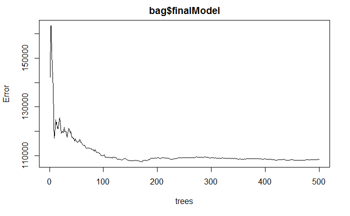

```r
plot(bag$finalModel)
```

Calculating variable importance helps us interpreting results from ensemble methods since now we have grown a lot of trees.

```r
varImp(bag)
```

```
rf variable importance

                      Overall
m2                    100.000
dist_to_center         29.561
rooms                  19.081
lat                    17.719
lon                    11.309
anteil_spd             10.699
anteil_afd              8.918
unemployment_rate       7.446
number_doctors          6.467
anteil_fdp              5.219
anteil_wähler           4.715
anteil_die_linke        4.039
foreigners_percentage   3.999
anteil_grüne            3.681
kita_number             3.314
anteil_cdu              2.797
average_age             0.000
```

However, we can take a look at the individual trees of the Bagging ensemble using `getTree`. Here are the first ten rows of the first two trees.

```r
getTree(bag$finalModel, k = 1, labelVar = T)[1:10,]
```

|  | left daughter | right daughter | split var | split point | status | prediction |
| --- | --- | --- | --- | --- | --- | --- |
| 1 | 2 | 3 | m2 | 135.865000 | -3 | 1455.7241 |
| 2 | 4 | 5 | m2 | 79.140000 | -3 | 1169.3435 |
| 3 | 6 | 7 | m2 | 179.000000 | -3 | 2980.9844 |
| 4 | 8 | 9 | m2 | 54.500000 | -3 | 858.0865 |
| 5 | 10 | 11 | m2 | 114.780000 | -3 | 1481.1159 |
| 6 | 12 | 13 | foreigners_percentage | 42.503709 | -3 | 2528.5522 |
| 7 | 14 | 15 | foreigners_percentage | 36.686818 | -3 | 3845.2459 |
| 8 | 16 | 17 | rooms | 1.250000 | -3 | 672.7404 |
| 9 | 18 | 19 | dist_to_center | 2.736821 | -3 | 996.8282 |
| 10 | 20 | 21 | dist_to_center | 3.481404 | -3 | 1347.9910 |

```r
getTree(bag$finalModel, k = 2, labelVar = T)[1:10,]
```

|  | left daughter | right daughter | split var | split point | status | prediction |
| --- | --- | --- | --- | --- | --- | --- |
| 1 | 2 | 3 | m2 | 142.500000 | -3 | 1395.7163 |
| 2 | 4 | 5 | m2 | 90.850000 | -3 | 1191.3841 |
| 3 | 6 | 7 | m2 | 179.000000 | -3 | 3173.9589 |
| 4 | 8 | 9 | m2 | 55.390000 | -3 | 958.1575 |
| 5 | 10 | 11 | m2 | 121.000000 | -3 | 1636.2519 |
| 6 | 12 | 13 | anteil_spd | 15.750000 | -3 | 2697.1681 |
| 7 | 14 | 15 | anteil_wähler | 70.650000 | -3 | 3835.3139 |
| 8 | 16 | 17 | rooms | 1.250000 | -3 | 699.1933 |
| 9 | 18 | 19 | anteil_afd | 8.550000 | -3 | 1094.1838 |
| 10 | 20 | 21 | dist_to_center | 3.730072 | -3 | 1491.1494 |

## Random Forest

Now we use `rf` as intended, i.e. we let `train` try out different numbers of `mtry`.

```r
set.seed(7324)
rf <- train(rent ~ .,
            data = fr_train,
            method = "rf",
            trControl = ctrl,
            importance = TRUE)
```

Now calling the random forest object lists the results of the tuning process.

```r
rf
```

```
Random Forest

1436 samples
  17 predictor

No pre-processing
Resampling: Cross-Validated (5 fold)
Summary of sample sizes: 1149, 1148, 1149, 1149, 1149
Resampling results across tuning parameters:

  mtry  RMSE      Rsquared
   2    428.7380  0.7709719
   9    326.9702  0.8471098
  17    336.2998  0.8401113

RMSE was used to select the optimal model using  the smallest value.
The final value used for the model was mtry = 9.
```

With random forests, the individuals trees of the ensemble should look quite different.

```r
getTree(rf$finalModel, k = 1, labelVar = T)[1:10,]
```

|  | left daughter | right daughter | split var | split point | status | prediction |
| --- | --- | --- | --- | --- | --- | --- |
| 1 | 2 | 3 | rooms | 3.750000 | -3 | 1403.8988 |
| 2 | 4 | 5 | m2 | 124.500000 | -3 | 1141.5088 |
| 3 | 6 | 7 | dist_to_center | 3.834378 | -3 | 2218.0572 |
| 4 | 8 | 9 | m2 | 65.570000 | -3 | 1061.1796 |
| 5 | 10 | 11 | unemployment_rate | 7.400000 | -3 | 2591.6625 |
| 6 | 12 | 13 | m2 | 155.235000 | -3 | 2505.2489 |
| 7 | 14 | 15 | anteil_grüne | 13.950000 | -3 | 1599.6895 |
| 8 | 16 | 17 | m2 | 38.675000 | -3 | 758.2708 |
| 9 | 18 | 19 | anteil_afd | 7.250000 | -3 | 1283.0068 |
| 10 | 20 | 21 | m2 | 142.300000 | -3 | 2325.9757 |

```r
getTree(rf$finalModel, k = 2, labelVar = T)[1:10,]
```

|  | left daughter | right daughter | split var | split point | status | prediction |
| --- | --- | --- | --- | --- | --- | --- |
| 1 | 2 | 3 | anteil_spd | 16.4000000 | -3 | 1459.599 |
| 2 | 4 | 5 | rooms | 3.7500000 | -3 | 1914.031 |
| 3 | 6 | 7 | anteil_grüne | 13.9500000 | -3 | 1228.564 |
| 4 | 8 | 9 | rooms | 2.2500000 | -3 | 1538.118 |
| 5 | 10 | 11 | foreigners_percentage | 23.2039327 | -3 | 2810.441 |
| 6 | 12 | 13 | anteil_fdp | 12.4000000 | -3 | 1057.444 |
| 7 | 14 | 15 | lon | 8.7041238 | -3 | 1446.241 |
| 8 | 16 | 17 | m2 | 89.0000000 | -3 | 1162.512 |
| 9 | 18 | 19 | dist_to_center | 0.5829637 | -3 | 1858.608 |
| 10 | 20 | 21 | lon | 8.6714142 | -3 | 2365.797 |

Especially for ensemble methods, plots can be useful in order to see how the features are related to the outcome according to the fitted model. This can be done separately by predictor…

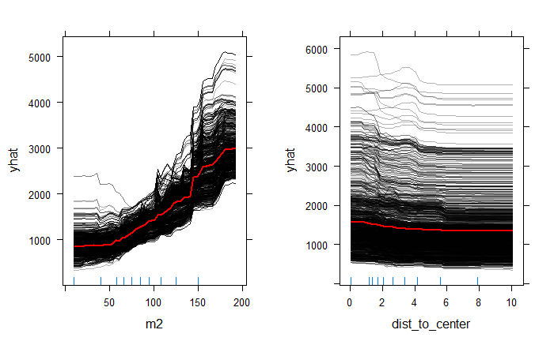

```r
pdp3 <- partial(rf, pred.var = "m2", ice = T, trim.outliers = T)
pdp4 <- partial(rf, pred.var = "dist_to_center", ice = T, trim.outliers = T)
p1 <- plotPartial(pdp3, rug = T, train = fr_train, alpha = 0.3)
p2 <- plotPartial(pdp4, rug = T, train = fr_train, alpha = 0.3)
grid.arrange(p1, p2, ncol = 2)
```

…and also by considering multiple predictors jointly.

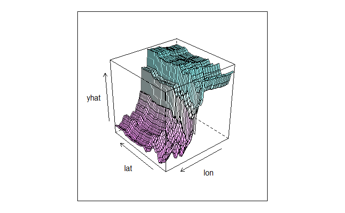

```r
pdp5 <- partial(rf, pred.var = c("lat", "lon"))
plotPartial(pdp5, levelplot = F, drape = T, colorkey = F, screen = list(z = 130, x = -60))
```

## Boosting

For Gradient Boosting, we have to take care of a couple of tuning parameters. Here, we use `xgboost` and build a grid with all combinations of a set of tryout values. See `?xgboost` for information on the available tuning parameters.

```r
grid <- expand.grid(max_depth = 1:3,
                    nrounds = c(500, 1000),
                    eta = c(0.05, 0.01),
                    min_child_weight = 5,
                    subsample = 0.7,
                    gamma = 0,
                    colsample_bytree = 1)
```

Again, this is passed on to `train`, now using `xgbTree` instead of `rf`.

```r
set.seed(7324)
xgb <- train(rent ~ .,
             data = fr_train,
             method = "xgbTree",
             trControl = ctrl,
             tuneGrid = grid)
```

Instead of just printing the results from the tuning process, we can also plot them.

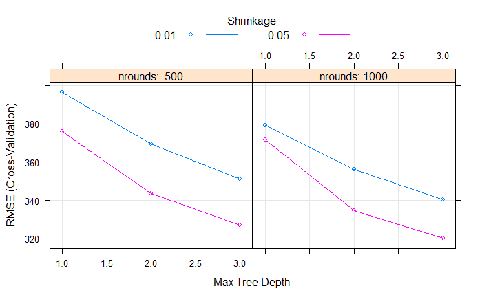

```r
plot(xgb)
```

## CART

Adding a single tree for comparison…

```r
grid <- expand.grid(maxdepth = 1:30)

set.seed(7324)
cart <- train(rent ~ .,
              data = fr_train,
              method = "rpart2",
              trControl = ctrl,
              tuneGrid = grid)
```

## Linear regression

…and also a linear regression model.

```r
set.seed(7324)
reg <- train(rent ~ .,
             data = fr_train,
             method = "glm",
             trControl = ctrl)
```

We may want to take a glimpse at the regression results.

```r
summary(reg)
```

```
Call:
NULL

Deviance Residuals:
    Min       1Q   Median       3Q      Max
-1630.9   -202.7    -35.1    143.0   3922.6

Coefficients:
                        Estimate Std. Error t value Pr(>|t|)
(Intercept)           -1.555e+05  3.635e+04  -4.277 2.02e-05 ***
m2                     1.727e+01  3.940e-01  43.831  < 2e-16 ***
rooms                 -1.082e+02  1.571e+01  -6.885 8.66e-12 ***
lon                   -2.220e+03  4.939e+02  -4.495 7.53e-06 ***
lat                    3.661e+03  7.751e+02   4.723 2.55e-06 ***
foreigners_percentage  1.061e+01  5.120e+00   2.073  0.03835 *
average_age            2.915e+01  1.110e+01   2.626  0.00874 **
kita_number            1.040e+00  2.103e+00   0.494  0.62105
number_doctors         4.792e-01  5.862e-01   0.817  0.41381
unemployment_rate     -1.542e+00  2.555e+01  -0.060  0.95189
anteil_wähler          9.644e+00  9.310e+00   1.036  0.30041
anteil_cdu            -1.085e+02  6.478e+01  -1.675  0.09414 .
anteil_spd            -1.031e+02  4.941e+01  -2.086  0.03716 *
anteil_afd            -1.494e+02  6.242e+01  -2.394  0.01680 *
anteil_die_linke      -1.271e+02  7.183e+01  -1.769  0.07705 .
anteil_grüne          -1.167e+02  5.057e+01  -2.308  0.02112 *
anteil_fdp            -9.202e+01  4.481e+01  -2.053  0.04021 *
dist_to_center        -5.787e+01  1.319e+01  -4.389 1.22e-05 ***
---
Signif. codes:  0 *** 0.001 ** 0.01 * 0.05 . 0.1   1

(Dispersion parameter for gaussian family taken to be 145677.1)

    Null deviance: 1045476156  on 1435  degrees of freedom
Residual deviance:  206570119  on 1418  degrees of freedom
AIC: 21168

Number of Fisher Scoring iterations: 2
```

## Comparison

After we ran a bunch of models, we can use `resamples` to gather the cross-validation results from all of them.

```r
resamps <- resamples(list(Bagging = bag,
                          RandomForest = rf,
                          Boosting = xgb,
                          CART = cart,
                          Regression = reg))
```

This object can now be used for comparing these models with respect to their performance, based on CV in the training set.

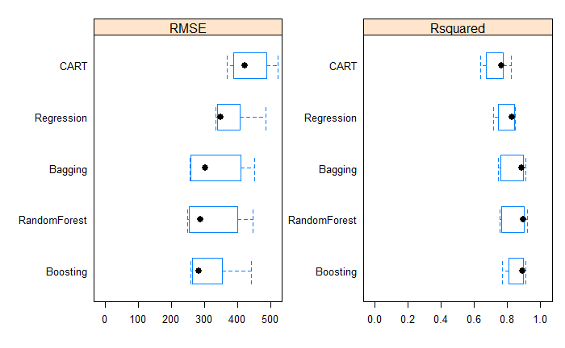

```r
bwplot(resamps, metric = c("RMSE", "Rsquared"), scales = list(relation = "free"), xlim = list(c(0, 500), c(0, 1)))
```

## Prediction

Finally, we can predict the outcome in the test data and evaluate the models based on their test set performance.

```r
y_bag <- predict(bag, newdata = fr_test)
y_rf <- predict(rf, newdata = fr_test)
y_xgb <- predict(xgb, newdata = fr_test)
y_cart <- predict(cart, newdata = fr_test)
y_reg <- predict(reg, newdata = fr_test)
postResample(pred = y_bag, obs = fr_test$rent)
```

```
       RMSE    Rsquared
356.2697478   0.8399483
```

```r
postResample(pred = y_rf, obs = fr_test$rent)
```

```
      RMSE   Rsquared
347.607284   0.848283
```

```r
postResample(pred = y_xgb, obs = fr_test$rent)
```

```
      RMSE   Rsquared
320.604215   0.870811
```

```r
postResample(pred = y_cart, obs = fr_test$rent)
```

```
       RMSE    Rsquared
468.2489701   0.7247648
```

```r
postResample(pred = y_reg, obs = fr_test$rent)
```

```
       RMSE    Rsquared
458.4633285   0.7349323
```